# Markov chain Monte Carlo sampling algorithms

Lecture 1

Dr Samuel Livingstone

# Welcome & Logistics

- Lectures: 14-15 & 23-25 April, 5070, 16:15-17:45
- Office hours by appointment (I’m in Warsaw until 27th April)
- E-mail: samuel.livingstone@ucl.ac.uk

# Module Outline

- Lecture 1: Mathematical preliminaries, sampling & Monte Carlo, rejection and importance sampling
- Lecture 2: Markov chains on general state spaces, introduction to MCMC
- Lecture 3: Metropolis–Hastings algorithm, Random Walk proposals, if time Gibbs sampler
- Lecture 4: Some MCMC theory
- Lecture 5: Advanced algorithms (Langevin, Hamiltonian, Tempering)

# Part 1: Preliminaries & motivation

# Notation

- We will work on the measurable space $(E,\mathcal{E})$ ($E$ polish, $\mathcal{E}$ Borel)
  - $E$ is outcome space, $\mathcal{E}$ is event space
- $\mu,\nu,\xi,\lambda$ etc. can denote probability measures/distributions/models
- If $X \sim \mu$ then
  $$\mathbb{P}(X \in A) = \mu(A)$$
  for all $A \in \mathcal{E}$
- We will write $\mu(A) = \int_A \mu(dx)$ and
  $$\mathbb{E}_\mu[f] = \int f(x) \mu(dx)$$
- If $\mu(dx)$ has a density then this will be written $\mu(x)$
- Discrete distributions can be expressed using the Dirac measure
  $$\delta_x(A) := \begin{cases} 1 & x \in A \\ 0 & x \notin A
  \end{cases}$$
- This allows a unified treatment of discrete & continuous random variables, and everything in between

# Notation: example 1

- $E = \mathbb{R}$
- The distribution $\nu$ is defined as
  $$\nu(A) := \frac{1}{\sqrt{2\pi}}\int_A e^{-\frac{x^2}{2}}dx$$
- **Question.** What is the name of this well-known distribution?
- Write
  $$\mathbb{E}_{\nu}[X^2] = \int x^2 \nu(dx) =
  \frac{1}{\sqrt{2\pi}}\int_A x^2 e^{-\frac{x^2}{2}}dx$$
- Formally we can say $\nu(dx) = \frac{1}{\sqrt{2\pi}}e^{-x^2/2}dx$
- **Question.** What is $\mathbb{E}_{\nu}[X^2]$ here?
- **Question.** What measure is $dx$?

# Notation: example 2

- $E = \{1,2,...,10\}$
- For any $A \in \mathcal{E}$ the distribution $\xi$ is defined as
  $$\xi(A) = \frac{1}{10} \sum_{i=1}^{10} \delta_i(A)$$
- **Question.** What is the name given to this probability distribution?
- Now
  $$\mathbb{E}_{\xi}[X^2] = \int x^2 \xi(dx) = \frac{1}{10}
  \sum_{i=1}^{10}\int x^2 \delta_i(dx) = \frac{1}{10}\sum_{i=1}^{10} i^2$$
  (recall that by definition $\int f(x) \delta_a(dx) = f(a)$)
- **Question.** If $Y$ is a random variable s.t. $\mathbb{P}(Y = 1) = 1/4$ and $\mathbb{P}(Y = 2) = 3/4$, how can we express the distribution of $Y$?
- **Question.** If $Z \sim \delta_0$ then what is $\mathbb{P}(Z = 0)$?

# Notation: final example

- $E = \mathbb{R}$, consider the following probability measure (with $\nu$ as in example 1)
  $$\lambda := \frac{1}{2}\nu + \frac{1}{2}\delta_0$$
- **Question.** If $X \sim \lambda$, what are $\mathbb{P}(X \geq 0)$ and $\mathbb{P}(X > 0)$?
- **Question.** Is $X$ discrete/continuous?
- We will need this level of notational flexibility later

# Motivation

- This course is motivated by two seemingly abstract problems
- **The Sampling Problem.** Given a finite measure $\pi_u$ on $(E,\mathcal{E})$, generate a sample
  $$X \sim \pi$$
  where $\pi(\cdot) := \pi_u(\cdot)/\pi_u(E)$ is the normalised version of $\pi_u$.
- **The Integration Problem.** Given the same $\pi_u$ and a function $f \in L^1(\pi_u)$, compute
  $$\mathbb{E}_\pi[f] = \int f(x)\pi(dx),$$
  with $\pi$ as above, to a desired degree of accuracy.
- These questions are ubiquitous in computational science (statistical physics, theoretical computer science, optimization, applied mathematics…)
  - We will focus on applications to statistics and statistical machine learning

# Part 2: Monte Carlo

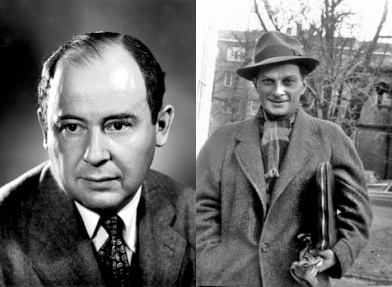

# Example: Inference in latent variable models

- Suppose we have a model with parameters $\theta$ and observations $x$ but also some latent structure $z$ (unobserved)
  - e.g. in a mixture model, $z$ might be the cluster allocations
- General structure is a log-likelihood of the form
  $$\ell(\theta;x) = \log\int p_\theta(x,z)dz$$
- How we can maximise the log-likelihood if this integral is **intractable**?

# Example (Classical significance testing)

- Suppose a statistical model with density $f_{\theta}$, $\theta$ unknown
- We wish to test
  $$H_{0}:\theta=\theta_{0}.$$
- We collect data $x=(x_{1},...,x_{n})$ with $x_i \in \mathcal{D}$, assumed to be iid samples from $f_\theta$
- Define a test statistic $T:\mathcal{D}^{n}\to[0,\infty)$, s.t. for any $y,z\in \mathcal{D}^n,$
  $$T(z)>T(y)$$
  means $H_0$ is more consistent with $y$ than $z$.
- The corresponding $p$-value is
  $$\mathbb{P}[T(X)\geq T(x)|H_{0}]=\int_{\{z:T(z)\geq T(x)\}}
  f_{\theta_{0}}(z_{1})...f_{\theta_{0}}(z_{n})dz_{1}...dz_{n}.$$
- **This is usually intractable if we don’t know the distribution for $T(X)$.**

# Example (Bayesian inference)

- Data $x=(x_{1},...,x_{n})$, assume the likelihood to be $f_{\theta}: \mathcal{D}^n \to [0,\infty)$, $\theta \in \mathbb{R}^d$ unknown
- Construct a prior density $\pi_{0}(\theta)$, and use Bayes’ theorem to update beliefs, giving a posterior
  $$\pi(\theta|x)=\frac{f_{\theta}(x)\pi_{0}(\theta)}{\int
  f_{\theta}(x)\pi_{0}(\theta)d\theta}.$$
- To learn from our model we typically want posterior summaries, e.g.
  $$\mathbb{E}_{\pi}[g(\theta)]=\int g(\theta)\pi(\theta|x)d\theta=\int
  g(\theta)\frac{f_{\theta}(x)\pi_{0}(\theta)}{\int
  f_{\vartheta}(x)\pi_{0}(\vartheta)d\vartheta}d\theta.$$
- **Both of these integrals may be intractable.**

# What is an intractable integral?

- A one-dimensional integral
  $$\int_{a}^{b}f(x)dx$$
  is said to be **intractable** if there is no *elementary* function $F$ such that
  $$\int_{a}^{b}f(x)dx=F(b)-F(a)$$
  for all $a,b\in\mathbb{R}$
- A function is called **elementary** if it can be written as the composition of a *finite* number of addition, subtraction, multiplication, division, exponential, logarithm, trigonometric, power or root operations
- An intractable integral is well-defined, just not easy to compute. Since Riemann and Lebesgue integrals agree when both are defined, when one is intractable then so is the other!
- (The extension to higher dimensions is straightforward)

# A simple example

- A very simple example of an intractable integral is
  $$\int_{a}^{b}e^{-\frac{1}{2}x^{2}}dx.$$
- **Question:** What is $\int_{-\infty}^\infty e^{-x^2/2}dx$?
- In other cases we may also have a tractable but expensive integral or sum that we would rather avoid: we call this *computationally intractable*
- E.g. imagine for large $n$ computing
  $$\sum_{i=1}^{n!} a_i$$
  for some sequence of real numbers $a_1,a_2,...$.

# Intractable integrals can look very innocent!

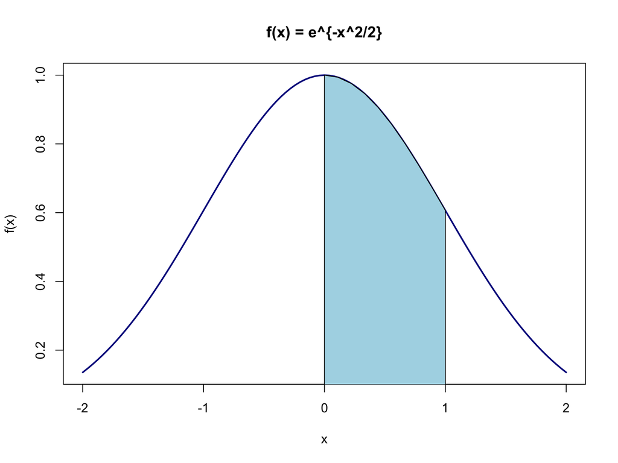

# Analytical intractability $\implies$ numerical methods

- When the analytical approach fails we resort to numerical methods for calculating the integral
- This is why you had to use $z$-tables and $t$-tables to compute p-values in your first course in Statistics!
- A popular low-dimensional strategy is quadrature rules, e.g. trapezium rule
  $$\int_{a}^{b}f(x)dx\approx\sum_{i=1}^{n}\frac{f(x_{i-1})+f(x_i)}{2}\delta
  x$$
- In 1D this is an effective strategy, but:
  - Assume $N$ grid squares are needed to well-approximate an integral in one dimension
  - This means $N^{d}=e^{dlog(N)}$ grid squares are needed in $d$-dimensions!
  - So the cost grows **exponentially** with dimension! *(curse of dimensionality)*

# Trapezium rule for 1D Gaussian density

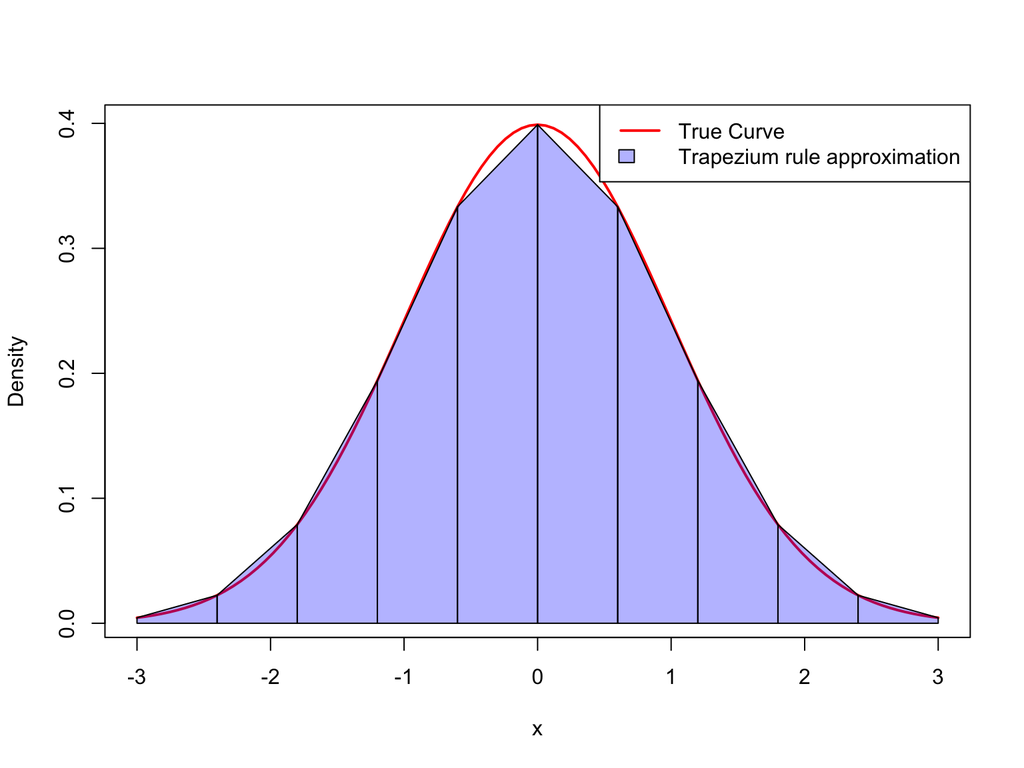

# The Monte Carlo Principle

*If an integral can be written as an expectation with respect to some probability distribution, we can approximate it by sampling from the distribution and computing the empirical average.*

# The Monte Carlo method

- Suppose we wish to calculate
  $$\mathbb{E}_{\pi}[f]:=\int f(x)\pi(dx).$$
- The Monte Carlo method:
  1. Draw $N$ samples $X_{1},...,X_{N} \sim \pi$
  2. Compute $\hat{f}_{N}:= \frac{1}{N} \sum_{i=1}^{N}f(X_{i})$.
- Note that this approach would be identical in $d$-dimensions. So if we are lucky **the curse of dimensionality will be broken.**

# Why does Monte Carlo work?

Monte Carlo works because of two fundamental results from probability theory

- **Theorem (Strong) Law of Large Numbers.** *Suppose that $X_{1},...,X_{N}$ are iid samples from $\pi(\cdot)$, and set $\hat{f}_{N}:=N^{-1}\sum_{i=1}^{N}f(X_{i})$. If $\mathbb{E}_{\pi}|f(X)|<\infty$, then as $N\to\infty$*
  $$\mathbb{P}\left(\lim_{N\to\infty}\hat{f}_{N}=\mathbb{E}_{\pi}[f]\right)=1.$$
- **Theorem (Central Limit Theorem).** *Suppose $X_{1},...,X_{N}$ are iid from $\pi(\cdot)$, and set $\hat{f}_{N}:=N^{-1}\sum_{i=1}^{N}f(X_{i})$. If $\mathbb{E}_{\pi}[f(X)^{2}]<\infty$ then as $N\to\infty$*
  $$\sqrt{N}\left(\hat{f}_{N}-\mathbb{E}_{\pi}[f]\right)\xrightarrow{d}
  \mathcal{N} \left(0,\text{Var}_{\pi}[f] \right)$$
- SLLN tells us that eventually Monte Carlo will work in many problems
- The CLT gives information about *rates* of convergence, and the shape of *fluctuations* in $\hat{f}_N$ as $N\to\infty$.

# A more statistical assessment of Monte Carlo

- We can consider $\hat{f}_N$ as an **estimator** for the unknown quantity $\mathbb{E}_\pi[f]$
- The **bias** of this estimator is
  $$\mathbb{E}[\hat{f}_N] - \mathbb{E}_\pi[f]$$
- The Monte Carlo estimator is **unbiased**, since
  $$\mathbb{E}[\hat{f}_N] = \mathbb{E} \left[ \frac{1}{N} \sum_{i=1}^N
  f(X_i) \right] = \frac{1}{N} \sum_{i=1}^N \mathbb{E}[f(X_i)] =
  \frac{1}{N} \cdot N \mathbb{E}_\pi[f]$$
- The **variance** of $\hat{f}_N$ is
  $$\text{Var}[\hat{f}_N] = \text{Var}\left( \frac{1}{N} \sum_i f(X_i)
  \right) = \frac{1}{N^2} \sum_i \text{Var}_\pi[f(X_i)] =
  \frac{1}{N}\text{Var}_\pi[f(X)]$$
- (The second equality holds because the samples are independent, a restriction that we will later relax)

# Some natural questions

- What if my integral isn’t an expectation?
  - For a general integral $\int g(x)dx$ one can write
    $$\int g(x)dx=\int\frac{g(x)}{\pi(x)}\pi(x)dx=\mathbb{E}_{\pi}[g/\pi]$$
  - How intelligent this is depends on $g$ and $\pi$ (we may return to this idea).
- How can I compute integrals between finite limits, e.g. probabilities?
  - We can use the indicator function
    $$\begin{aligned}
    \mathbb{I}_{[a,b]}(x) & :=\begin{cases}
    1 & a\leq x\leq b\\
    0 & \text{otherwise.}
    \end{cases}
    \end{aligned}$$
    This gives
    $$\mathbb{P}[a\leq X\leq b]=\int_{a}^{b}\pi(dx)=\int\mathbb{I}_{[a,
    b]}(x)\pi(dx)=\mathbb{E}_{\pi}[\mathbb{I}_{[a, b]}(X)],$$
    which can then be evaluated in the usual way.
- How do I draw samples from a probability distribution?
  - This is what we will discuss throughout the course!

# Part 3: Sampling from a probability distribution

# The big picture

- Generating a sample from a probability distribution $\pi$ takes a few steps:
  1. Generate a sample from $U[0,1]$ distribution
     - Actually *pseudo-random* samples
  2. If possible, *directly* transform this into a sample from $\pi$
  3. If not then resort to *indirect* approaches
- In the interests of time I will not cover step 1 (ask if interested)

# Direct sampling via transformations

- Assume that we have a $U[0,1]$ sample $u$
- We can transform this to generate samples from lots of different distributions.
- The key piece of intuition is
  $$\mathbb{P}[U\leq u]=F_{U}(u)=u$$
  for any $u\in[0,1]$.
- This also means that
  $$\mathbb{P}[a<U<b]=b-a$$
  for $a,b\in[0,1]$ with $a\leq b$.

# Bernoulli sampling

- If $U\sim U[0,1]$ and we set
  $$\begin{aligned}
  X=\begin{cases}
  1 & U\leq p\\
  0 & U>p
  \end{cases}
  \end{aligned}$$
  for some known $p\in[0,1]$, then $X\sim\text{Bernoulli}(p)$.
- *Proof.* $\mathbb{P}[X=1]=\mathbb{P}[U\leq p]=F_{U}(p)=p,$ and a similar calculation can be made for $\mathbb{P}[X=0]$ (try it if unsure!).

# A more complex example

- Consider a more complex example
  $$\mathbb{P}[X=i]=p_{i}$$
  for $i\geq1$
- Write
  $$c_{i}:=\sum_{j=1}^{i}p_j.$$
- To generate a sample:
  1. Draw $U\sim U[0,1]$
  2. Set $X=i$ if $c_{i-1}<U\leq c_{i}$
- **Exercise.** Can you prove that the above procedure will generate a sample from the correct distribution?

# Graphical representation of the discrete case

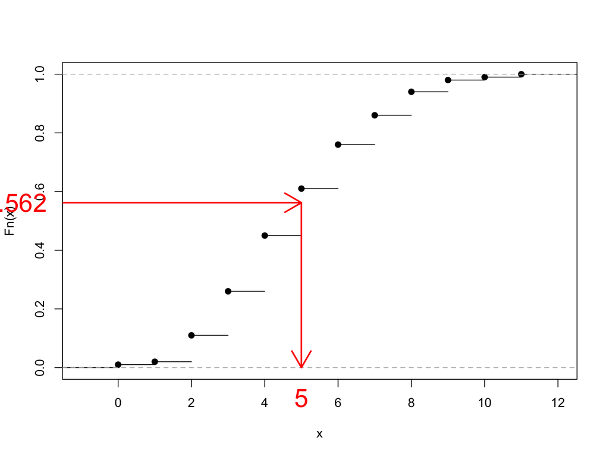

# Continuous case: Inverse CDF method

- If $U\sim U[0,1]$ and $F_{X}$ is the CDF for $X$ with $F_{X}^{-1}$ known, then
  $$X\stackrel{d}{=}F_{X}^{-1}(U).$$
- *Proof.* Show CDFs are equal:
  $$\mathbb{P}[F_{X}^{-1}(U)\leq x]=\mathbb{\mathbb{P}}[U\leq
  F_{X}(x)]=F_{X}(x)=\mathbb{P}[X\leq x].$$

# Example (Exponential distribution)

- If $X\sim\text{Exp}(\lambda)$, then for $x > 0$
  $$F(x) := 1-e^{-\lambda x} \implies F^{-1}(u) :=
  -\frac{1}{\lambda}\log(1-u)$$
- Using the Inverse CDF method then gives
  $$X\stackrel{d}{=}-\frac{1}{\lambda}\log(1-U),$$
  where $U \sim U[0,1]$.
- **Question:** In this case $-\frac{1}{\lambda}\log(U)$ would also work. Can you see why?

# Example (Exponential distribution)

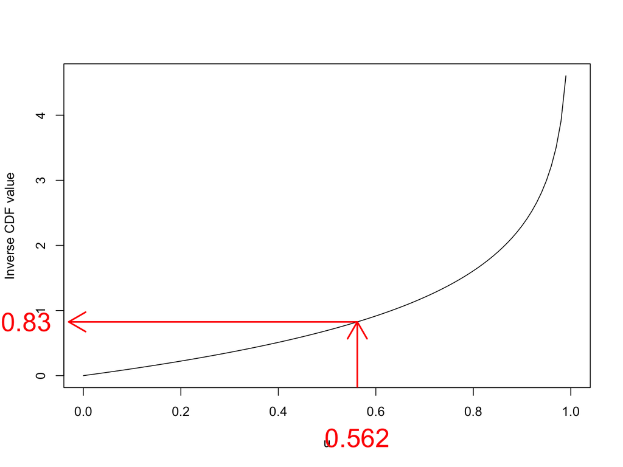

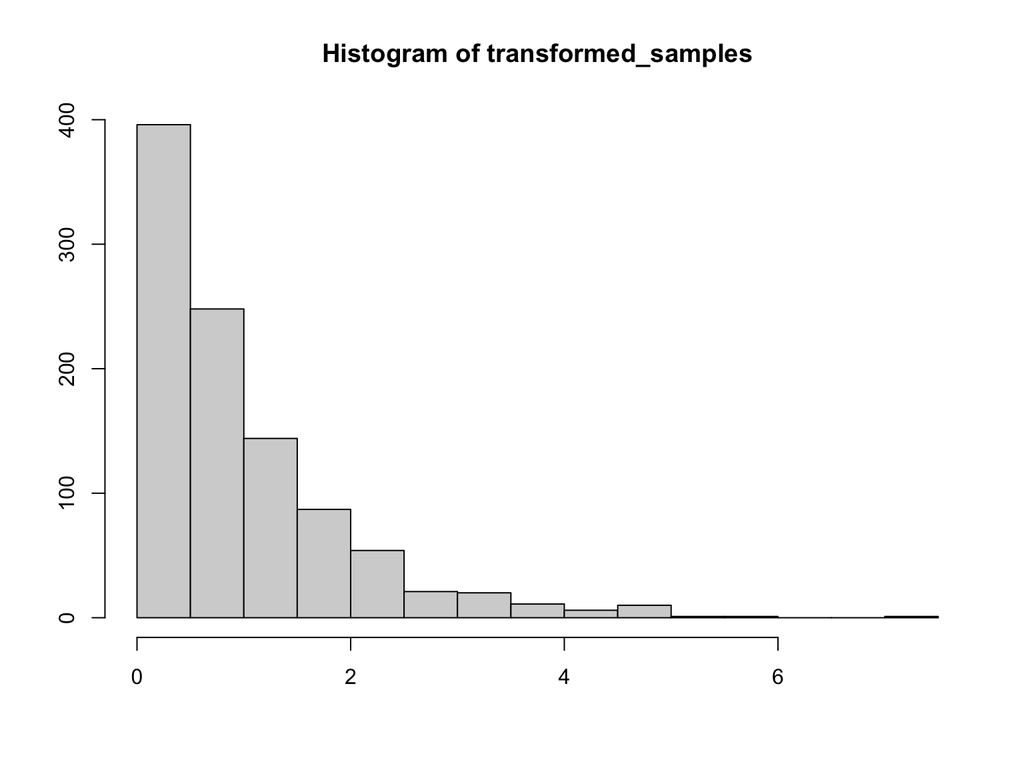

```r
uniform_samples <- runif(1000)
transformed_samples <- -log(1-uniform_samples)
hist(transformed_samples, xlab = "", ylab = "")
```

# Limitations

- The inverse CDF method is very powerful, but requires an expression for $F_X^{-1}$
  - **Question.** Can you think of a distribution for which this cannot be easily derived?
- Another way to generate samples is to build a r.v. by combining others
  - If $Y\sim\text{Gamma}(n,\lambda)$, then one can write
    $$Y\stackrel{d}{=}\sum_{i=1}^{n}X_{i},$$
    where each $X_{i}\stackrel{iid}\sim\text{Exp}(\lambda)$
- This is also not always possible: we need more flexibility

# Indirect Sampling

- Indirect sampling refers to the idea of post-processing samples in some other way than a direct transformation or combination
- This usually results in some **loss of computational efficiency** compared to direct sampling
  - But often it is all we can do!
- We will look at two approaches
  - rejection sampling
  - importance sampling

# Rejection sampling: simple example

- Roll a regular six-sided dice, label result $X$
- If $X \leq 3$, keep it
- Otherwise throw it away
- **Questions.**
  1. From which distribution are we sampling?
  2. How many iterations of this procedure are needed to generate $N$ samples?

# How could we modify the procedure to draw samples from this distribution?

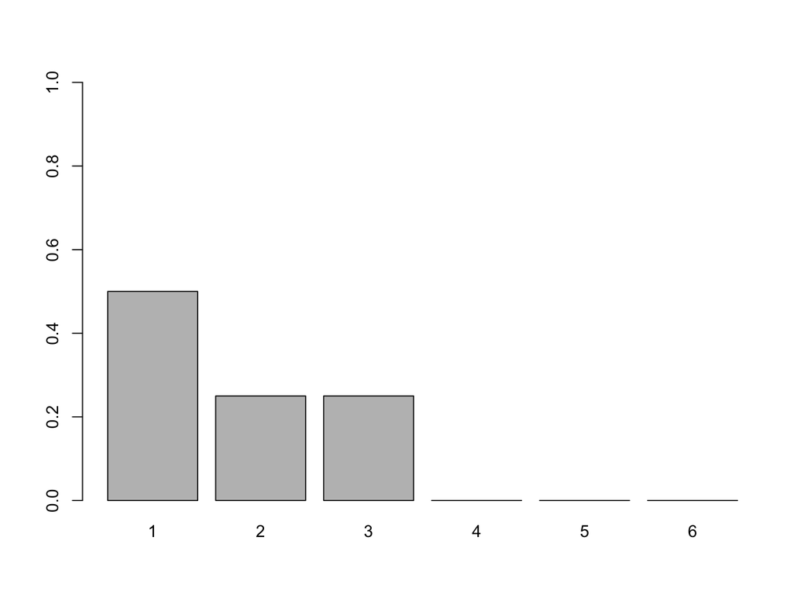

# We can write the *target* and *candidate* distributions mathematically…

$$\begin{aligned}
\pi &= (1/2,1/4,1/4,0,0,0) \\
q &= (1/6,1/6,1/6,1/6,1/6,1/6)
\end{aligned}$$

**Question:** How would the problem change if $q = (1/3,1/3,1/3)$ instead?

# Rejection sampling: main idea

- Goal: sampling from **target** distribution $\pi$
- Choose some *candidate* distribution $q$
- Sample $X \sim q$, *reject* some of the samples

# Rejection Sampling Algorithm

- Set $i \leftarrow 0$
- While $i < N$
  - Draw $X \sim q$
  - Draw $U \sim \mathcal{U}[0,1]$
  - If
    $$U \leq \frac{\pi(X)}{Mq(X)},$$
    accept $X$ as a sample and set $i \leftarrow i + 1$
- EndWhile
- **Questions:**
  1. How many samples would this algorithm produce?
  2. Which element of the algorithm is currently undefined?

# The constant $M$

- In the above
  $$M := \sup_x \frac{\pi(x)}{q(x)}.$$
- In the first example $M = 2$, in the second $M = 3$
- **Question:** Why is $M$ chosen in this way? = **Question.** What happens if $M = \infty$

# Modified example worked calculation

- $\pi = (1/2,1/4,1/4,0,0,0)$
- $q = (1/6,1/6,1/6,1/6,1/6,1/6)$
- $M = 3$.
- This means the acceptance probabilities are
  $$\frac{\pi(1)}{Mq(1)} = 1, ~ \frac{\pi(2)}{Mq(2)} = 1/2, ~
  \frac{\pi(3)}{Mq(3)} = 1/2,$$
  with all others being $0$.

# A continuous example

- Take $\pi$ to be $N(0,1)$
- Set $q$ to be $N(0,\sigma^2)$, for $\sigma > 1$.
  $$M = \sup_x \frac{\pi(x)}{q(x)} = \frac{\pi(0)}{q(0)} =
  \frac{1\sqrt{2\pi}}{1/\sqrt{2\pi\sigma^2}} = \sigma.$$

# Example in the case $\sigma = 3$

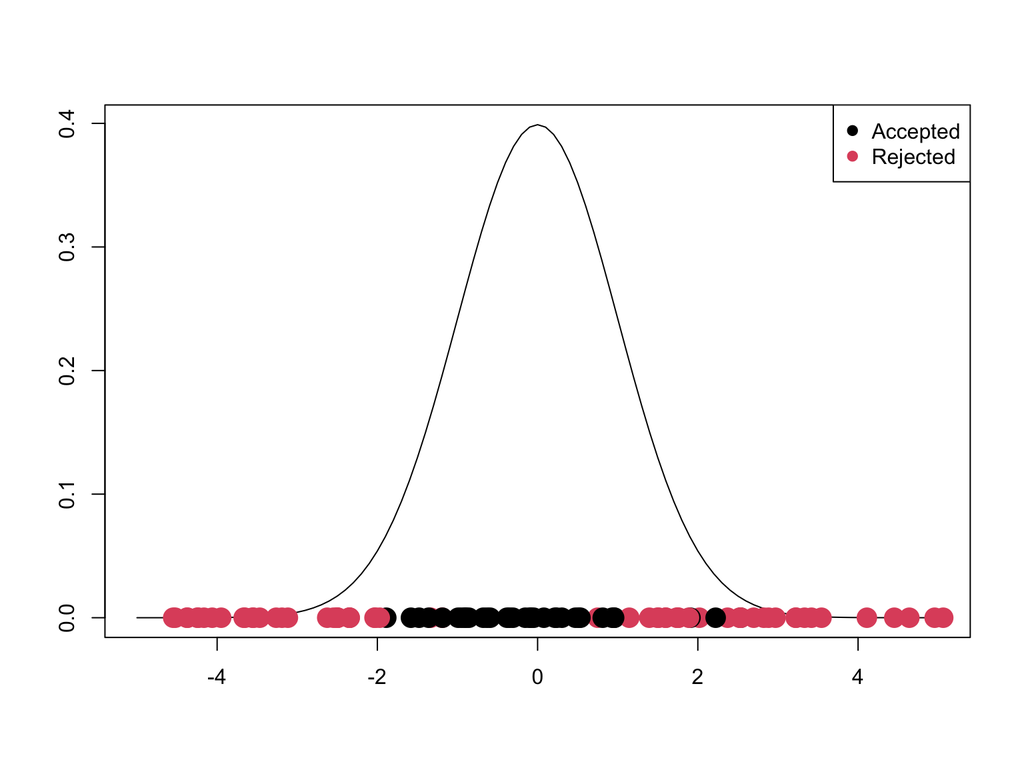

# Proof that the rejection sampling algorithm produces samples from $\pi$ (in case $\pi$ & q have densities)

- For any event $A$ if $X \sim q$ then
  $$\mathbb{P}[X\in A|X\text{ accepted}] =\frac{\mathbb{P}[X\in A,X\text{
  accepted}]}{\mathbb{P}[X\text{ accepted}]}$$
- Note that for any $A \in \mathcal{E}$ (using the disintegration theorem)
  $$\mathbb{P}[X \in A, X\text{ accepted}] = \int_A \mathbb{P}[X\text{
  accepted}|X = x]q(x)dx = \int_A \frac{\pi(x)}{Mq(x)}q(x)dx$$
- (This is just an integral form of $\mathbb{P}(B) = \sum_i \mathbb{P}(B | A_i)\mathbb{P}(A_i)$)
- We can therefore write
  $$\mathbb{P}[X\in A|X\text{ accepted}] = \frac{\mathbb{P}[X\in A, X\text{
  accepted}]}{\mathbb{P}[X\text{ accepted}]} =
  \frac{\int_{A}q(x)\frac{\pi(x)}{Mq(x)}dx}{\int_{E}q(x)\frac{\pi(x)}{Mq(x)}dx}
  = \frac{\frac{1}{M}\int_{A}\pi(x)dx}{\frac{1}{M}\int_{E}\pi(x)dx} =
  \pi(A)$$

# What proportion of samples will be accepted?

- From above, the probability that a sample from $q$ will be accepted is
  $$\mathbb{P}[\text{accepted}]=\int
  q(x)\frac{\pi(x)}{Mq(x)}dx=\frac{1}{M}\int\pi(x)dx=\frac{1}{M}.$$
- So it is desirable to choose $q$ s.t. $M$ is **as small as possible** (i.e. $q \approx \pi$)
- For example, when the target is $N(0,1)$ and candidate $N(0,\sigma)$ for $\sigma>1$, then
  $$M = \sigma$$

# The tails of $q$ should be at least as heavy as $\pi$ for finite $M$ (here $\pi$ qs $N(0,1)$, $q$ is $N(0,1/2)$)

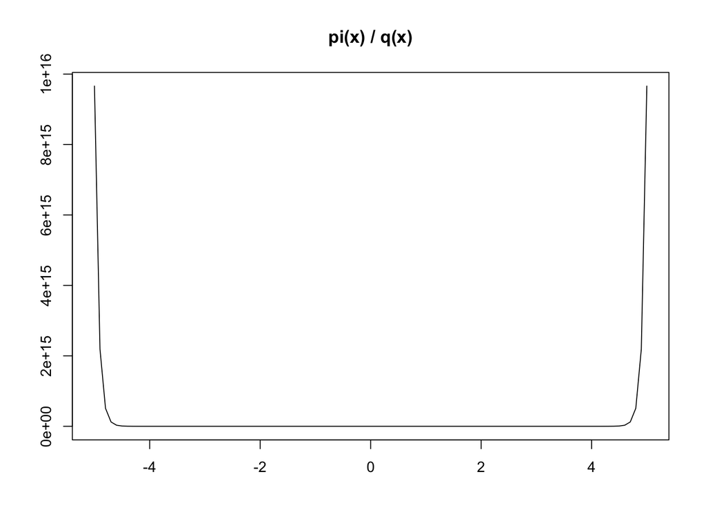

# Towards a more general algorithm

- The above holds when $\pi$ and $q$ have densities wrt Lebesgue measure
- In general we need the measure $\pi$ to be absolutely continuous with respect to $q$
- The acceptance rate can then be constructed as
  $$\frac{1}{M} \cdot\frac{d\pi}{dq}(x)$$
  (i.e. $1/M$ multiplied by the Radon–Nikodym derivative of $\pi$ wrt $q$)

# Importance sampling

- The basic identity on which the importance sampling method is based is
  $$\mathbb{E}_\pi[f(X)]=\int f(x)\pi(dx) = \int
  f(x)\frac{\pi(dx)}{q(dx)}q(dx)=\mathbb{E}_q\left[f(X)\frac{d\pi}{dq}(X)\right].$$
- We typically write
  $$w(X) := \frac{d\pi}{dq}(X),$$
  and call $w$ the *importance weight*
- **Question.** When $\pi$ and $q$ both have densities wrt Lebesgue measure what do the weights become?

# (Naive) Importance Sampling Algorithm

1. Draw $X_i \sim q$ for $1\leq i\leq N$
2. For each $i$ compute the importance weights
   $$w(X_i):= \frac{d\pi}{dq}(X_i)$$
3. Compute
   $$\hat{f}^{IS-n}_N := \frac{1}{N}\sum_{i=1}^N w(X_i)f(X_i)$$
- This is not really a sampling algorithm, it’s a way to perform Monte Carlo for one distribution using samples from another.

# The bias & variance of the naive IS estimator

- The naive estimator is unbiased (proof straightforward, hence omitted)
- Recall that in ordinary Monte Carlo the estimator $\hat{f}_N$ has variance
  $$\begin{aligned}
  \text{Var}[\hat{f}_N] &= \frac{1}{N}\text{Var}_\pi[f(X)] \\
  &= \frac{1}{N}\left( \mathbb{E}_\pi[f(X)^2] - \mathbb{E}_\pi[f(X)]^2
  \right).
  \end{aligned}$$
- In the naive IS case this variance is instead
  $$\begin{aligned}
  \text{Var}[\hat{f}_N^{IS-n}] &= \frac{1}{N}\text{Var}_q [f(X)w(X)]
  \\
  &= \frac{1}{N}\left( \mathbb{E}_q[w(X)^2f(X)^2] -
  \mathbb{E}_q[w(X)f(X)]^2 \right).
  \end{aligned}$$
- When $w$ is an unbounded function of $x$, this can be **infinite** for many choices of $f$
- **Question.** How should the tails of $\pi$ and $q$ behave for $w(x)$ to be bounded/unbounded?

# Self-normalised importance sampling

- We have seen that the naive IS estimator can have infinite variance
- It is also not computable when only $c\pi$ is known (e.g. Bayesian inference)
- We can instead replace the weights with their *normalised* version
  $$\tilde{w}(X_i) := \frac{w(X_i)}{\sum_{i=1}^N w(X_i)}$$
- We can then use the estimator
  $$\hat{f}_N^{IS} = \sum_{i=1}^N \tilde{w}(X_i)f(X_i)$$
- This often stabilises the variance, but introduces a small bias for finite $N$. It’s generally preferred

# The ‘effective’ sample size

- How many independent samples from $\pi$ do we need to produce a Monte Carlo estimator with variance $\text{Var}[\hat{f}^{IS}_N]$?
- Recall $\text{Var}[\hat{f}_N] = \frac{1}{N}\text{Var}_\pi[f]$. We can set
  $$\text{Var}[\hat{f}_N^{IS}] := \frac{1}{N_\text{eff}}\text{Var}_\pi[f]$$
  for some $N_{\text{eff}} > 0$, which we call the **effective sample size**.
- A simple approximation (derivation omitted) is given by
  $$N_{eff} \approx \frac{1}{\sum_{i=1}^N \tilde{w}_i^2}.$$
- This is independent of $f$, and gives a useful heuristic for measuring the quality of an IS estimator.

# Effective sample size: intuition

- $N_{eff}$ will be smaller when $\sum_i \tilde{w}_i^2$ is larger
- This occurs when the weights have a high variance
  $$N\hat{f}_N^{IS} = \tilde{w}_1 f(x_1) + ... + \tilde{w}_n f(x_n).$$
- E.g. if $\tilde{w}_2=...=\tilde{w}_N \approx 0$ and $\tilde{w}_1 \gg 1$ the estimate is only really relying on a single sample $x_1$
  - The resulting estimator will probably be poor
  - Note that $\sum_i \tilde{w}_i^2 \approx \tilde{w}_i^2 \gg \tilde{w}_i \gg 1$ here